# PARİTE: SIĞIR — Veri Analizi Defteri

### 1 birim sığır, kaç birim yem ediyor? · ABD (1971–2026) · AB (2015–2026) · Türkiye (2010–2026)

**Namık Akman · namikakman.dev** · Veri kesimi: Haz/Tem 2026

Bu defter, aynı adlı 15 sayfalık raporun ve "Parite: Sığır" veri-belgeselinin **tekrarlanabilir analiz omurgasıdır**. 993 aylık gözlem; üç resmî kaynak (FRED/BLS · EC Agrifood · TÜİK/EVDS); tek metodoloji.

> **Parite** = sığır fiyat serisi ÷ yem fiyat serisi. Pay üreticinin geliri, payda en büyük maliyeti. Oran birimden bağımsızdır, enflasyondan büyük ölçüde arınıktır ve "1 kilo hayvan satıp kaç kilo yem alırım?" sorusunun cevabıdır.

**İçindekiler:** 1. Kurulum ve veri · 2. Yönetici özeti (sayılarla) · 3. ABD: 55 yılın anatomisi · 4. Döngü laboratuvarı · 5. Isı haritası: 55 yıl tek karede · 6. AB ve Türkiye · 7. Üç kıta yan yana · 8. Senkronizasyon · 9. Sonuç

```python
# 1 · KURULUM VE VERİ
import json, urllib.request, numpy as np
import matplotlib.pyplot as plt
import matplotlib.dates as mdates
from matplotlib.ticker import MaxNLocator
from datetime import datetime

# Görsel dil: film/rapor ile aynı palet
AMBER='#D97E1F'; BLUE='#5B74B8'; RED='#C0453A'; INK='#2A2118'; GRID='#E8E2D6'; PALE='#F7F3EA'
plt.rcParams.update({'font.family':'DejaVu Sans','figure.facecolor':'white','axes.facecolor':'white',
 'axes.grid':True,'grid.color':GRID,'grid.linewidth':.8,'axes.spines.top':False,'axes.spines.right':False,
 'axes.edgecolor':INK,'text.color':INK,'axes.labelcolor':INK,'xtick.color':INK,'ytick.color':INK,
 'figure.dpi':110,'savefig.dpi':160})

RAW='https://raw.githubusercontent.com/namikakmandev/namikakmandev.github.io/main/data/'
import os
def load(name):
    local=f'/home/user/namikakmandev.github.io/data/{name}'
    if os.path.exists(local): d=json.load(open(local))
    else:
        with urllib.request.urlopen(RAW+name) as r: d=json.load(r)
    return d
us=load('cattle-us.json'); eu=load('cattle-eu.json'); tr=load('cattle-tr.json'); par=load('cattle-parity.json')

def unpack(d):
    m=[r[0] for r in d['rows']]; v=np.array([r[3] for r in d['rows']],float)
    t=np.array([datetime(int(x[:4]),int(x[5:]),15) for x in m])
    return m,v,t
us_m,us_v,us_t=unpack(us); eu_m,eu_v,eu_t=unpack(eu); tr_m,tr_v,tr_t=unpack(tr)
print(f'ABD: {len(us_v)} ay ({us_m[0]}→{us_m[-1]}) · AB: {len(eu_v)} ay · TR: {len(tr_v)} ay · toplam {len(us_v)+len(eu_v)+len(tr_v)}')
```

```
ABD: 666 ay (1971-01→2026-06) · AB: 129 ay · TR: 198 ay · toplam 993
```

## 2 · Yönetici özeti — sayılarla

Aşağıdaki hücre, raporun beş temel bulgusunu **canlı veriden** yeniden hesaplar (kopyala-yapıştır sayı yok).

```python
# 2 · TEMEL BULGULAR (hesaplanmış)
def pct_rank(v): return (v[:-1]<v[-1]).mean()*100
line='─'*66
print(line)
for ad,m,v in [('ABD',us_m,us_v),('AB ',eu_m,eu_v),('TR ',tr_m,tr_v)]:
    i_mx=int(np.argmax(v)); i_mn=int(np.argmin(v))
    print(f'{ad} · bugün {v[-1]:.2f}× ({m[-1]}) · yüzdelik %{pct_rank(v):.1f} · '
          f'zirve {v[i_mx]:.2f} ({m[i_mx]}) · dip {v[i_mn]:.2f} ({m[i_mn]})')
print(line)
dec={}
for mm,vv in zip(us_m,us_v): dec.setdefault(mm[:3]+'0',[]).append(vv)
print('ABD onyıl ortalamaları:', ' → '.join(f"{k}'ler {np.mean(x):.2f}" for k,x in sorted(dec.items())))
def yoy(m,v):
    d=dict(zip(m,v)); return {mm:vv/d[f'{int(mm[:4])-1}-{mm[5:]}']-1 for mm,vv in zip(m,v) if f'{int(mm[:4])-1}-{mm[5:]}' in d}
uy,ey,ty=yoy(us_m,us_v),yoy(eu_m,eu_v),yoy(tr_m,tr_v)
def corr(a,b):
    ks=sorted(set(a)&set(b)); return np.corrcoef([a[k] for k in ks],[b[k] for k in ks])[0,1]
print(f'Yıllık değişim korelasyonları: ABD–AB {corr(uy,ey):.2f} · AB–TR {corr(ey,ty):.2f} · ABD–TR {corr(uy,ty):.2f}')
print(line)
print('MESAJ: Yem belirler — yem pahalanınca sürü küçülür; sürü küçülünce et, her kıtada pahalanır.')
```

```
──────────────────────────────────────────────────────────────────
ABD · bugün 2.44× (2026-06) · yüzdelik %99.8 · zirve 2.54 (2025-08) · dip 0.40 (1974-12)
AB  · bugün 2.82× (2026-07) · yüzdelik %88.3 · zirve 3.51 (2026-02) · dip 1.42 (2022-06)
TR  · bugün 1.31× (2026-06) · yüzdelik %92.9 · zirve 1.40 (2024-04) · dip 0.70 (2021-12)
──────────────────────────────────────────────────────────────────
ABD onyıl ortalamaları: 1970'ler 0.80 → 1980'ler 1.00 → 1990'ler 1.07 → 2000'ler 1.22 → 2010'ler 1.10 → 2020'ler 1.34
Yıllık değişim korelasyonları: ABD–AB 0.88 · AB–TR 0.68 · ABD–TR 0.58
──────────────────────────────────────────────────────────────────
MESAJ: Yem belirler — yem pahalanınca sürü küçülür; sürü küçülünce et, her kıtada pahalanır.
```

## 3 · ABD: 55 yılın anatomisi

Ana grafik: şok dönemleri gölgeli, dip/zirveler işaretli, son değer vurgulu.

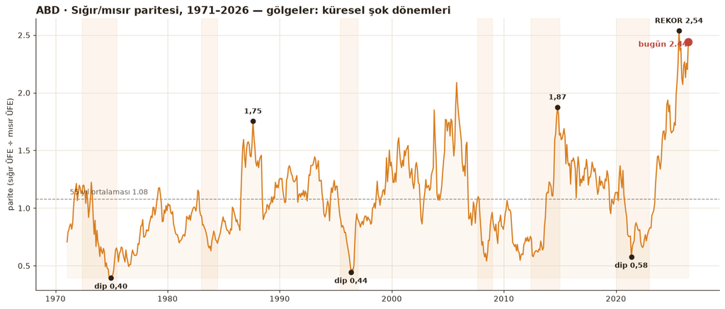

```python
# 3 · ABD ANA GRAFİK — dönem gölgeleri + uç noktalar
fig,ax=plt.subplots(figsize=(13,5.6))
# şok bantları (olay takvimi, rapor Bölüm 4)
bands=[('1972-06','1975-06','Tahıl şoku'),('1983-01','1984-06','PIK+kuraklık'),
       ('1995-06','1996-12','Stok krizi'),('2007-09','2008-12','Gıda-yakıt'),
       ('2012-06','2014-12','Kuraklık'),('2020-03','2022-12','Pandemi+savaş')]
for a,b,lb in bands:
    ax.axvspan(datetime(int(a[:4]),int(a[5:]),1),datetime(int(b[:4]),int(b[5:]),28),color=AMBER,alpha=.08)
ax.plot(us_t,us_v,color=AMBER,lw=1.5,zorder=3)
ax.fill_between(us_t,us_v,us_v.min(),color=AMBER,alpha=.06,zorder=2)
ax.axhline(us_v.mean(),color=INK,ls='--',lw=1,alpha=.5)
ax.text(us_t[3],us_v.mean()+.04,f'55 yıl ortalaması {us_v.mean():.2f}',fontsize=9,alpha=.7)
marks=[('1974-12','dip 0,40',-14),('1987-08','1,75',10),('1996-05','dip 0,44',-14),
       ('2014-10','1,87',10),('2021-05','dip 0,58',-14),('2025-08','REKOR 2,54',10)]
dm=dict(zip(us_m,us_v))
for mm,lb,dy in marks:
    x=datetime(int(mm[:4]),int(mm[5:]),15); y=dm[mm]
    ax.scatter([x],[y],s=34,color=INK,zorder=4)
    ax.annotate(lb,(x,y),textcoords='offset points',xytext=(0,dy),ha='center',
                fontsize=9,fontweight='bold',zorder=5)
ax.scatter([us_t[-1]],[us_v[-1]],s=90,color=RED,zorder=5)
ax.annotate(f'bugün {us_v[-1]:.2f}',(us_t[-1],us_v[-1]),textcoords='offset points',
            xytext=(-64,-6),fontsize=10,color=RED,fontweight='bold')
ax.set_title('ABD · Sığır/mısır paritesi, 1971–2026 — gölgeler: küresel şok dönemleri',
             loc='left',fontsize=13,fontweight='bold')
ax.set_ylabel('parite (sığır ÜFE ÷ mısır ÜFE)')
plt.tight_layout(); plt.show()
```

**Okuma:** Gölgeli her şok bandının içinde ya bir dip ya bir zirve saklı. Şokların kaynağı her seferinde farklı (jeopolitika → iklim → enerji → salgın), verideki imzası hep aynı: payda şoku dip yapar, arz şoku zirve.

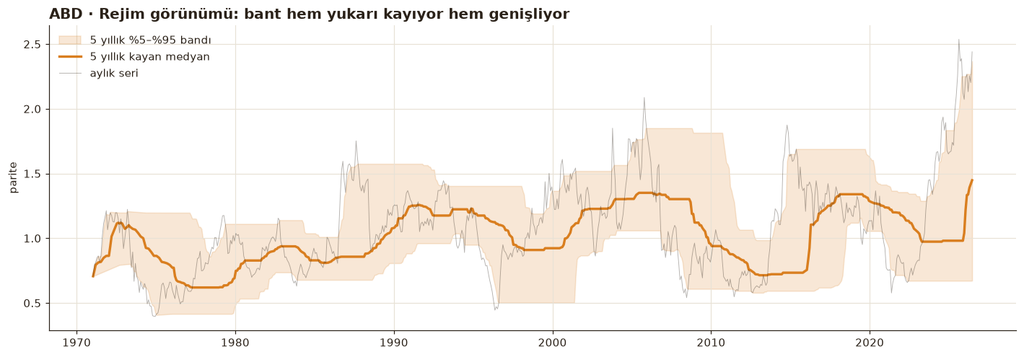

```
Kayan medyan: 1980'de 0.75 → 2000'de 0.92 → bugün 1.45
```

```python
# 3b · REJİM: 5 yıllık kayan bant (medyan + %5-%95)
w=60
med=np.array([np.median(us_v[max(0,i-w):i+1]) for i in range(len(us_v))])
lo=np.array([np.percentile(us_v[max(0,i-w):i+1],5) for i in range(len(us_v))])
hi=np.array([np.percentile(us_v[max(0,i-w):i+1],95) for i in range(len(us_v))])
fig,ax=plt.subplots(figsize=(13,4.6))
ax.fill_between(us_t,lo,hi,color=AMBER,alpha=.18,label='5 yıllık %5–%95 bandı')
ax.plot(us_t,med,color=AMBER,lw=2.2,label='5 yıllık kayan medyan')
ax.plot(us_t,us_v,color=INK,lw=.6,alpha=.35,label='aylık seri')
ax.legend(frameon=False,loc='upper left')
ax.set_title('ABD · Rejim görünümü: bant hem yukarı kayıyor hem genişliyor',loc='left',fontsize=13,fontweight='bold')
ax.set_ylabel('parite')
plt.tight_layout(); plt.show()
print(f"Kayan medyan: 1980'de {med[us_m.index('1980-01')]:.2f} → 2000'de {med[us_m.index('2000-01')]:.2f} → bugün {med[-1]:.2f}")
```

## 4 · Döngü laboratuvarı

En güçlü kanıt: **dört büyük dibi üst üste bindirelim.** Her yörünge, dip ayında 100'e eşitlenir ve izleyen 60 ay izlenir. Eğer "sığır döngüsü" gerçekse, dört farklı on yılın çizgileri aynı şekli çizmelidir.

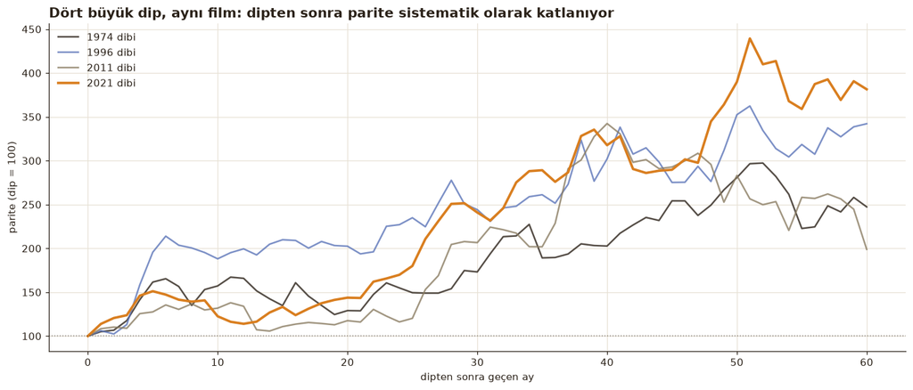

```
1974 dibi: 60 ayda ×3.0 (zirveye 52 ayda)
1996 dibi: 60 ayda ×3.6 (zirveye 51 ayda)
2011 dibi: 60 ayda ×3.4 (zirveye 40 ayda)
2021 dibi: 60 ayda ×4.4 (zirveye 51 ayda)
```

```python
# 4 · DİP SONRASI YÖRÜNGELER (dip=100, sonraki 60 ay)
dips=['1974-12','1996-05','2011-06','2021-05']
fig,ax=plt.subplots(figsize=(12.5,5.4))
colors_c=[INK,BLUE,'#8a7c62',AMBER]
for dip,c in zip(dips,colors_c):
    i=us_m.index(dip); seg=us_v[i:i+61]
    ax.plot(range(len(seg)),seg/seg[0]*100,color=c,lw=2.4 if dip=='2021-05' else 1.6,
            label=f'{dip[:4]} dibi',alpha=1 if dip=='2021-05' else .8)
ax.axhline(100,color=INK,ls=':',lw=1,alpha=.5)
ax.set_xlabel('dipten sonra geçen ay'); ax.set_ylabel('parite (dip = 100)')
ax.legend(frameon=False)
ax.set_title('Dört büyük dip, aynı film: dipten sonra parite sistematik olarak katlanıyor',
             loc='left',fontsize=13,fontweight='bold')
plt.tight_layout(); plt.show()
for dip in dips:
    i=us_m.index(dip); seg=us_v[i:i+61]
    print(f'{dip[:4]} dibi: 60 ayda ×{seg.max()/seg[0]:.1f} (zirveye {int(np.argmax(seg))} ayda)')
```

## 5 · 55 yıl tek karede: yıl × ay ısı haritası

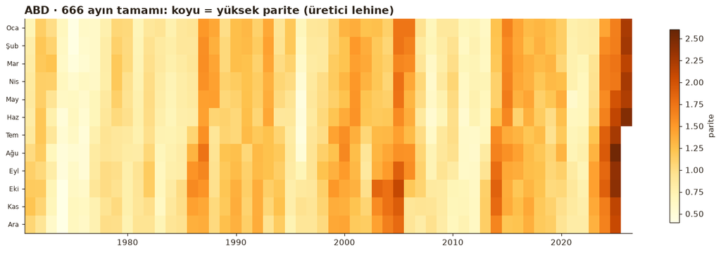

[output not shown]

```python
# 5 · ISI HARİTASI (yıl × ay)
years=sorted({int(m[:4]) for m in us_m})
Z=np.full((12,len(years)),np.nan)
for mm,vv in zip(us_m,us_v):
    Z[int(mm[5:])-1, years.index(int(mm[:4]))]=vv
fig,ax=plt.subplots(figsize=(13.5,4.4))
im=ax.imshow(Z,aspect='auto',cmap='YlOrBr',vmin=0.4,vmax=2.6,
             extent=[years[0]-.5,years[-1]+.5,12.5,0.5])
ax.set_yticks(range(1,13)); ax.set_yticklabels(['Oca','Şub','Mar','Nis','May','Haz','Tem','Ağu','Eyl','Eki','Kas','Ara'],fontsize=8)
ax.grid(False)
cb=fig.colorbar(im,ax=ax,shrink=.9); cb.set_label('parite')
ax.set_title('ABD · 666 ayın tamamı: koyu = yüksek parite (üretici lehine)',loc='left',fontsize=13,fontweight='bold')
plt.tight_layout(); plt.show()
print('Sağ üstteki koyu blok = 2023–26 rekor bölgesi. Dikey açık şeritler = 1974, 1996, 2021 yem şokları.')
print('Yatay desen: Eyl–Eki satırları sistematik koyu → hasat mevsimselliği.')
```

## 6 · AB ve Türkiye: aynı rüzgâr, farklı sahne

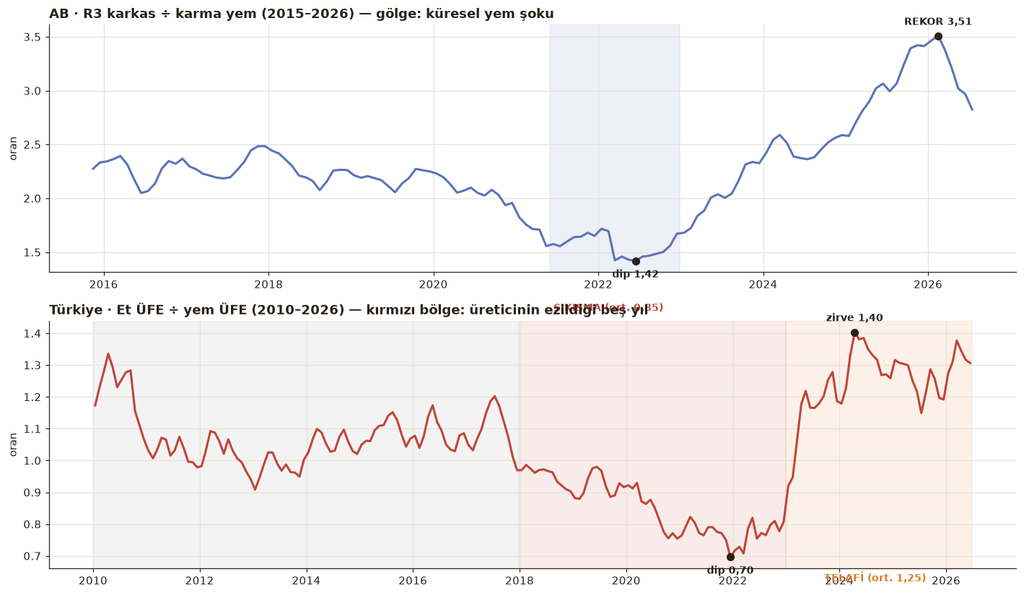

```python
# 6 · AB + TR (dönem gölgeli ikili panel)
fig,axs=plt.subplots(2,1,figsize=(13,7.6),sharex=False)
ax=axs[0]
ax.axvspan(datetime(2021,6,1),datetime(2022,12,28),color=BLUE,alpha=.10)
ax.plot(eu_t,eu_v,color=BLUE,lw=2)
de=dict(zip(eu_m,eu_v))
for mm,lb,dy in [('2022-06','dip 1,42',-15),('2026-02','REKOR 3,51',10)]:
    x=datetime(int(mm[:4]),int(mm[5:]),15)
    ax.scatter([x],[de[mm]],s=40,color=INK,zorder=4)
    ax.annotate(lb,(x,de[mm]),textcoords='offset points',xytext=(0,dy),ha='center',fontsize=9,fontweight='bold')
ax.set_title('AB · R3 karkas ÷ karma yem (2015–2026) — gölge: küresel yem şoku',loc='left',fontsize=12,fontweight='bold')
ax.set_ylabel('oran')
ax=axs[1]
for a,b,c,al in [('2010-01','2017-12',INK,.05),('2018-01','2022-12',RED,.10),('2023-01','2026-06',AMBER,.10)]:
    ax.axvspan(datetime(int(a[:4]),int(a[5:]),1),datetime(int(b[:4]),int(b[5:]),28),color=c,alpha=al)
ax.plot(tr_t,tr_v,color=RED,lw=2)
dt_=dict(zip(tr_m,tr_v))
for mm,lb,dy in [('2021-12','dip 0,70',-15),('2024-04','zirve 1,40',10)]:
    x=datetime(int(mm[:4]),int(mm[5:]),15)
    ax.scatter([x],[dt_[mm]],s=40,color=INK,zorder=4)
    ax.annotate(lb,(x,dt_[mm]),textcoords='offset points',xytext=(0,dy),ha='center',fontsize=9,fontweight='bold')
ax.text(datetime(2019,9,1),1.47,'SIKIŞMA (ort. 0,85)',fontsize=9,color=RED,fontweight='bold',ha='center')
ax.text(datetime(2024,9,1),0.62,'TELAFİ (ort. 1,25)',fontsize=9,color=AMBER,fontweight='bold',ha='center')
ax.set_title('Türkiye · Et ÜFE ÷ yem ÜFE (2010–2026) — kırmızı bölge: üreticinin ezildiği beş yıl',loc='left',fontsize=12,fontweight='bold')
ax.set_ylabel('oran')
plt.tight_layout(); plt.show()
```

## 7 · Üç kıta yan yana (2015 = 100)

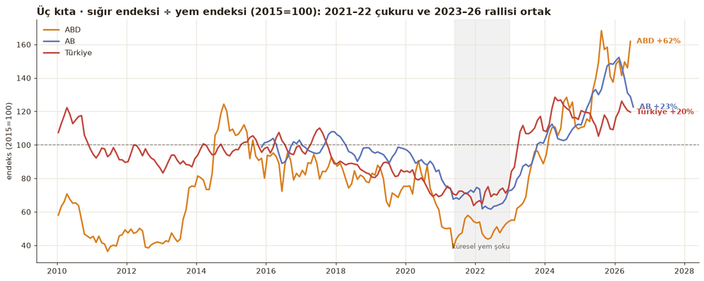

```python
# 7 · ENDEKS KARŞILAŞTIRMA + son değer etiketleri
fig,ax=plt.subplots(figsize=(13,5.2))
ax.axvspan(datetime(2021,6,1),datetime(2022,12,28),color=INK,alpha=.06)
ax.text(datetime(2022,3,1),38,'küresel yem şoku',fontsize=8.5,ha='center',alpha=.7)
for k,c,lb in [('US',AMBER,'ABD'),('EU',BLUE,'AB'),('TR',RED,'Türkiye')]:
    rows=par['regions'][k]['rows']
    t=[datetime(int(r[0][:4]),int(r[0][5:]),15) for r in rows]; v=[r[3]*100 for r in rows]
    ax.plot(t,v,color=c,lw=2,label=lb)
    ax.annotate(f'{lb} {v[-1]-100:+.0f}%',(t[-1],v[-1]),textcoords='offset points',
                xytext=(8,0),color=c,fontweight='bold',fontsize=10,va='center')
ax.axhline(100,color=INK,ls='--',lw=1,alpha=.5)
ax.set_xlim(datetime(2009,6,1),datetime(2028,6,1))
ax.legend(frameon=False,loc='upper left')
ax.set_title('Üç kıta · sığır endeksi ÷ yem endeksi (2015=100): 2021–22 çukuru ve 2023–26 rallisi ortak',
             loc='left',fontsize=13,fontweight='bold')
ax.set_ylabel('endeks (2015=100)')
plt.tight_layout(); plt.show()
```

## 8 · Senkronizasyon: kıtalar aynı dalgada mı?

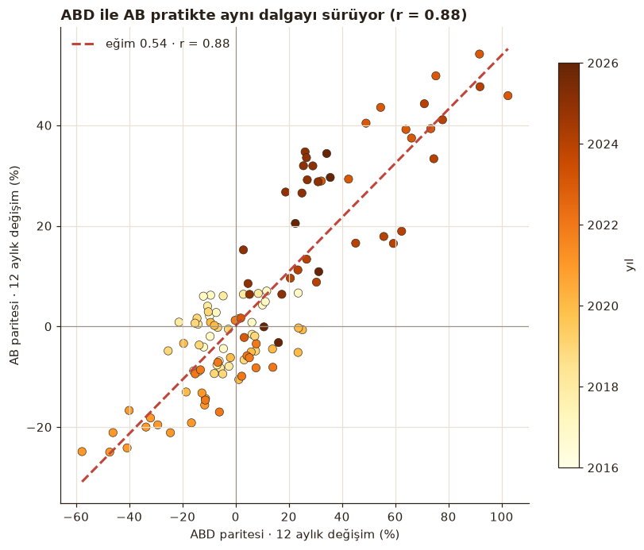

```
ABD–TR korelasyonu 0.58, AB–TR 0.68: Türkiye küresel dalga + kur bileşkesi.
```

```python
# 8 · ABD–AB YILLIK DEĞİŞİM SAÇILIMI + regresyon
ks=sorted(set(uy)&set(ey))
x=np.array([uy[k] for k in ks])*100; y=np.array([ey[k] for k in ks])*100
b,a=np.polyfit(x,y,1); r=np.corrcoef(x,y)[0,1]
fig,ax=plt.subplots(figsize=(7.6,6.4))
yrs=np.array([int(k[:4]) for k in ks])
sc=ax.scatter(x,y,c=yrs,cmap='YlOrBr',s=46,edgecolor=INK,linewidth=.4)
xx=np.linspace(x.min(),x.max(),10)
ax.plot(xx,a+b*xx,color=RED,lw=2,ls='--',label=f'eğim {b:.2f} · r = {r:.2f}')
cb=fig.colorbar(sc,ax=ax,shrink=.85); cb.set_label('yıl')
ax.axhline(0,color=INK,lw=.8,alpha=.4); ax.axvline(0,color=INK,lw=.8,alpha=.4)
ax.set_xlabel('ABD paritesi · 12 aylık değişim (%)'); ax.set_ylabel('AB paritesi · 12 aylık değişim (%)')
ax.legend(frameon=False)
ax.set_title('ABD ile AB pratikte aynı dalgayı sürüyor (r = %.2f)'%r,loc='left',fontsize=12,fontweight='bold')
plt.tight_layout(); plt.show()
print(f'ABD–TR korelasyonu {corr(uy,ty):.2f}, AB–TR {corr(ey,ty):.2f}: Türkiye küresel dalga + kur bileşkesi.')
```

## 9 · Sonuç

**Sınırlamalar:** TR serisi işlenmiş-et proxy'sidir; AB oranı farklı birimlerdedir (bu yüzden karşılaştırma 2015=100 endeksiyle yapılır); ÜFE çiftlik-kapısı marjı değildir.

*Veri ve kod: github.com/namikakmandev/namikakmandev.github.io — `data/cattle-*.json`, `scripts/fetch_cattle_data.py`. PDF rapor: `notes/parite-sigir-veri-raporu.pdf`. Film: "Parite: Sığır".*